# As unidades acadêmicas da UFCG

Hadrizia Santos

Esse documento tem como objetivo agrupar as unidades acadêmicas da UFCG. O relatório inicial que serviu como base para este foi feito pelo professor Nazareno Andrade e pode ser encontrado [aqui](https://github.com/nazareno/tamanhos-da-ufcg).

## 1. Importando dados e bibliotecas

```r
library(tidyverse)
library(lubridate)
library(viridis)
library(DT)
library(here)
library(plyr)
library(broom)
library(ggfortify)
library(plotly)
```

```r
ufcg_uas = readr::read_csv(here::here("data/ufcg-201704-sumario-UAs-wide.csv"),
                            col_types = cols(
                                UORG_LOTACAO = col_character(),
                                Outro = col_double(),
                                `Professor 20h` = col_double(),
                                `Professor 40h ou DE` = col_double(),
                                idade_25perc = col_double(),
                                idade_mediana = col_double(),
                                idade_75perc = col_double()
                            ))
colnames(ufcg_uas) <- c('ua', 'outros_funcionarios', 'professor_20h', 'professor_40h_ou_DE',
                      'idade_25perc', 'idade_mediana', 'idade_75perc')
```

As colunas dos dados estão descritas abaixo:

- `ua` Unidade acadêmica de lotação do funcionário
- `outros_funcionarios` Número de funcionários na UA que não são professores
- `professor_20h` Número de professores com carga horária 20h/semana na UA
- `professor_40h_ou_DE` Número de professores com carga horária 40h/semana na UA, sejam eles Dedicação Exclusiva ou não
- `idade_25perc`, `idade_mediana` e `idade_75perc` : 25, 50 e 75 percentil da idade dos funcionários *no cargo* (ex: idade_25perc = 10 significa que 25% dos funcionários, sejam eles professores ou não, da UA tem 10 anos ou menos na profissão.)

## 2. Agrupando os dados

Deseja-se agrupar os dados de acordo com 4 variáveis: O número de funcionários que não são professores, o número de professores com carga horária de 40h/semana, o número de professores com carga horária de 20h/semanais e a idade_75perc, que indica o tempo de trabalho de 75% dos funcionários. O método usado para este agrupamento será o *k-means*, um método procura particionar as observações dentre k grupos, onde cada observação pertence ao grupo mais próximo da média (centróide). Mais sobre o k-means pode ser encontrado neste [site](http://www.diegonogare.net/2015/08/entendendo-como-funciona-o-algoritmo-de-cluster-k-means/).

### 2.1. Escolhendo o K no algoritmo

O K é a quantidade de centróides (pontos centrais dos grupos) que serão criados e ajudará a encontrará a similaridade dos dados. Há duas formas comumente utilizadas: a GAP statistic, que é mais robusta, mas precisa de mais dados para isso, e between/total sum of squares, que é mais comum, e menos robusta. Como se trata de poucos dados, a forma utilizada será a between/total sum of squares.

**Between/total sum of squares**: compara a distância (quadrática) entre o centro dos clusters e o centro dos dados com a distância (quadrática) entre os pontos todos nos dados e o centro dos dados. Mais sobre o Between/totss pode ser encontrado [aqui](https://github.com/nazareno/ciencia-de-dados-1/blob/master/3-Agrupamento-e-PCA/2-kmeans-e-mais-exemplos.Rmd#betweentotss).

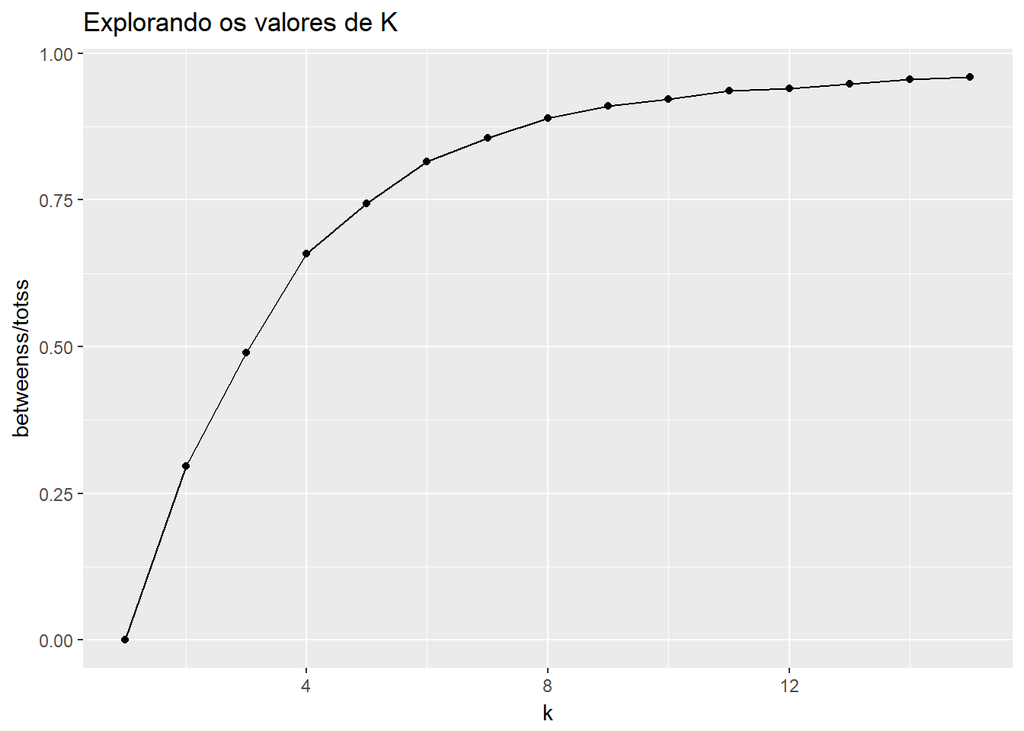

```r
# Setando a partição reproduzível
set.seed(123)

# Setando o válor máximo de k entre 1 e 10
k = 1:15

explorando_k = (tibble(k)) %>%
    group_by(k) %>%
    do(
        kmeans(select(ufcg_uas, -ua, -idade_mediana, -idade_25perc),
               centers = .$k,
               nstart = 20) %>% glance()
    )

explorando_k %>%
    ggplot(aes(x = k, y = betweenss / totss)) +
    geom_line() +
    geom_point() + ggtitle("Explorando os valores de K")
```

Um k ótimo é aquele que, depois dele, o betweenss / totss não cresce tanto a medida que o k cresce. A partir do gráfico se pode ver que depois de 4, à medida que o k cresce, p betweenss / totss vai crescendo em proporção menor do que estava até o k chegar a 4. Isto indica que 4 é o nosso k ótimo.

### 2.2. Visualizando os agrupamentos

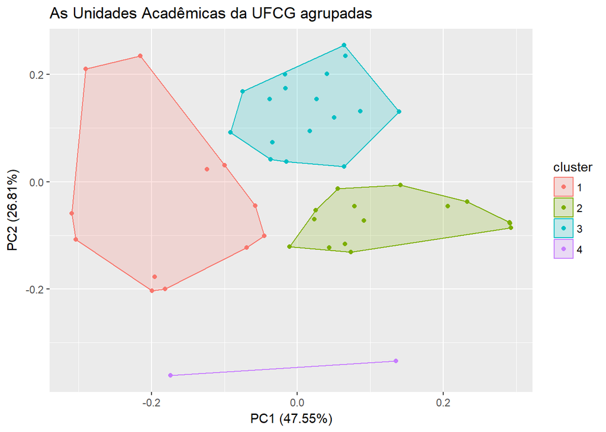

```r
n_clusters = 4

ufcg_uas %>%
  select(-ua, -idade_mediana, -idade_25perc) %>%
    kmeans(n_clusters, iter.max = 100, nstart = 20) -> km

autoplot(km, data=ufcg_uas %>%
  select(-ua, -idade_mediana, -idade_25perc), frame = TRUE) + ggtitle("As Unidades Acadêmicas da UFCG agrupadas")
```

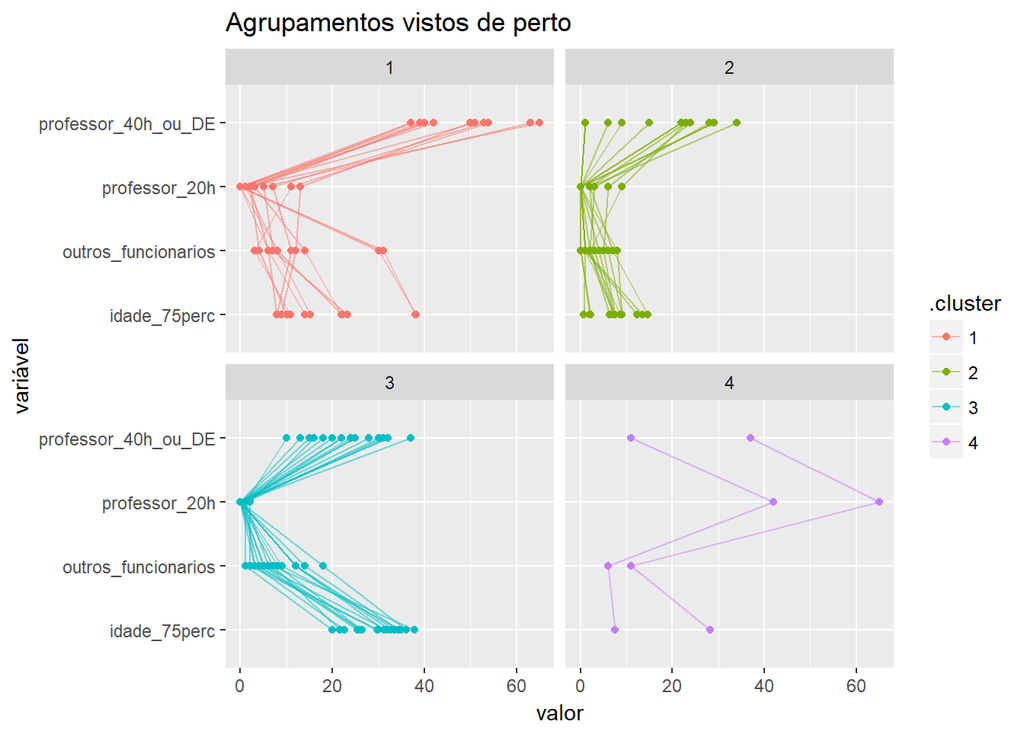

```r
ua_agrupadas = km %>%
  augment(ufcg_uas) %>%
  gather(key = "variável",
         value = "valor",
         -ua,
         -idade_mediana,
         -idade_25perc,
         -.cluster)

ua_agrupadas %>%
  ggplot(aes(x = `variável`,
             y = valor,
             group = ua,
             label = ua,
             colour = .cluster)) +
  geom_line(alpha = .5) +
    geom_point() +
  coord_flip() +
  facet_wrap(~ .cluster) +
 ggtitle("Agrupamentos vistos de perto")
```